# Mainly Loops (+ Functions = Animations)

[EFB 654: R and Reproducible Research](https://eligurarie.github.io/EFB654/)

Elie Gurarie

February 18, 2026

# Loops

## Simple `for` loop

```r
for(i in 1:10)
  print(i)
```

```
## [1] 1
## [1] 2
## [1] 3
## [1] 4
## [1] 5
## [1] 6
## [1] 7
## [1] 8
## [1] 9
## [1] 10
```

`i` is the loop variable — it takes each value in the sequence, one at a time. `i` is the most common name, but it’s arbitrary.

## Pay attention to notation

```r
names <- c("Aditya", "Bob", "Changzi", "Demetrious", "Ed")

# indexing style: i goes from 1 to the length of the vector
for(i in 1:length(names))
  print(nchar(names[i]))
```

```
## [1] 6
## [1] 3
## [1] 7
## [1] 10
## [1] 2
```

## Pre-allocate a container

Often you want to *save* results from a loop, not just print them. Make an empty container first, then fill it in.

```r
nchars <- rep(NA, length(names))
for(i in 1:length(names))
  nchars[i] <- nchar(names[i])
nchars
```

```
## [1]  6  3  7 10  2
```

## Loop variable doesn’t have to be an integer (or `i`)

```r
for(n in names){
  print(n)
  print(nchar(n))
}
```

```
## [1] "Aditya"
## [1] 6
## [1] "Bob"
## [1] 3
## [1] "Changzi"
## [1] 7
## [1] "Demetrious"
## [1] 10
## [1] "Ed"
## [1] 2
```

saving results with element-based looping using named vector

```r
nchars <- rep(NA, length(names))
names(nchars) <- names

for(n in names)
  nchars[n] <- nchar(n)
nchars
```

```
##     Aditya        Bob    Changzi Demetrious         Ed
##          6          3          7         10          2
```

## Avoiding loops with `apply`

In R, loops can often be avoided with the `apply` family of functions:

```r
sapply(names, nchar)
```

```
##     Aditya        Bob    Changzi Demetrious         Ed
##          6          3          7         10          2
```

Also `plyr` / `dplyr` / tidyverse — we’ll discuss this later.

# Uses of loops

## True iteration

Some problems genuinely require loops because each step depends on the previous one.

### Fibonacci sequence

```r
fib <- rep(NA, 12)
fib[1] <- 1
fib[2] <- 1

for(i in 3:length(fib)){
  fib[i] <- fib[i-1] + fib[i-2]
}
fib
```

```
##  [1]   1   1   2   3   5   8  13  21  34  55  89 144
```

[figure not shown]

Note, a very natural thing to wrap in a function:

```r
computeFib <- function(n){
  fib <- rep(NA, n)
  fib[1] <- 1
  fib[2] <- 1

  for(i in 3:length(fib)){
    fib[i] <- fib[i-1] + fib[i-2]
  }
  fib
}
```

```r
f20 <-computeFib(20)
f20[20]/f20[19]
```

```
## [1] 1.618034
```

```r
(1+sqrt(5))/2
```

```
## [1] 1.618034
```

## Looping through files

A very common real-world use: processing a batch of data files.

```
files <- list.files("path/to/csvs")
```

Example file listing from a CTT wildlife tracking project:

```
 [1] "CTT-V3033D437786-blu.2026-03-11_014627.csv"
 [2] "CTT-V3033D437786-blu.2026-03-11_024628.csv"
 [3] "CTT-V3033D437786-blu.2026-03-11_044631.csv"
 [4] "CTT-V3033D437786-blu.2026-03-11_164645.csv"
 [5] "CTT-V3033D437786-blu.2026-03-12_044659.csv"
 [6] "CTT-V3033D437786-blu.2026-03-12_104707.csv"
 [7] "CTT-V3033D437786-blu.2026-03-12_154714.csv"
 [8] "CTT-V3033D437786-blu.2026-03-12_184717.csv"
 [9] "CTT-V3033D437786-blu.2026-03-13_074733.csv"
[10] "CTT-V3033D437786-blu.2026-03-13_104736.csv"
[11] "CTT-V3033D437786-blu.2026-03-13_134739.csv"
[12] "CTT-V3033D437786-gps.2026-03-12_184717.csv"
```

```r
for(f in files){
  mycsv <- read.csv(f)
  # do something with mycsv
}
```

## `while` loops

A `while` loop repeats as long as a condition is `TRUE`. The condition is checked *before* each iteration. Example below finds runs the Fibonacci iteration up to a certain value:

```r
fib <- c(1, 1)
while(fib[length(fib)] < 1000){
  fib <- c(fib, fib[length(fib)] + fib[length(fib)-1])
}
fib
```

```
##  [1]    1    1    2    3    5    8   13   21   34   55   89  144  233  377  610
## [16]  987 1597
```

**Be careful** — if the condition never becomes `FALSE`, the loop runs forever:

```r
# Do NOT run this
while(x > 1){
  x <- x + 1
  cat(paste(x, " "))
}
```

### Example: finding the maximum of a function

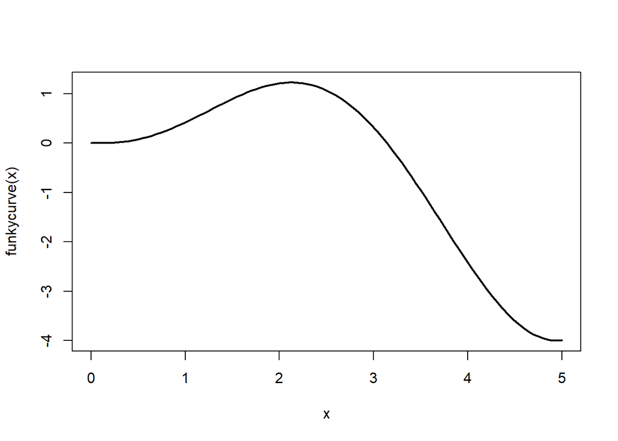

```r
funkycurve <- function(x) x^2 * sin(x) / (1 + x)
curve(funkycurve(x), xlim = c(0, 5), lwd = 2)
```

A simple `while` loop to find the max between 0 and 5 within a tolerance of 0.001:

```r
lo <- 0
hi <- 5
tol <- 0.001

while((hi - lo) > tol){
  mid <- (lo + hi) / 2
  if(funkycurve(mid + tol) > funkycurve(mid - tol)){
    lo <- mid
  } else {
    hi <- mid
  }
}
mid
```

```
## [1] 2.125854
```

```r
funkycurve(mid)
```

```
## [1] 1.228714
```

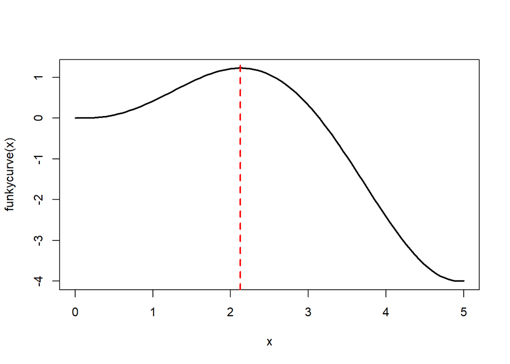

```r
curve(funkycurve(x), xlim = c(0, 5), lwd = 2)
abline(v = mid, lty = 2, col = "red", lwd = 2)
```

> Think through how this algorithm works….

# Combining loops with functions

## Looping through years of WDI data

```r
load("WDI_allyears.rda")
with(WDI, table(country))
```

Define a plotting function:

```r
plotWDI <- function(myyear, ...){

  cols <- c("East Asia & Pacific"        = "steelblue",
            "Europe & Central Asia"      = "forestgreen",
            "Latin America & Caribbean"  = "goldenrod",
            "Middle East & North Africa" = "darkorange",
            "North America"              = "mediumpurple",
            "South Asia"                 = "firebrick",
            "Sub-Saharan Africa"         = "sienna")

  mywdi <- subset(WDI, year == myyear)
  mywdi_big <- mywdi[order(mywdi$Population, decreasing = TRUE),][1:10,]

  cont_col <- cols[match(mywdi$region, levels(mywdi$region))]
  cex_pop  <- sqrt(mywdi$Population / max(mywdi$Population, na.rm = TRUE)) * 15

  with(mywdi, {
    plot(GDP/1e3, LifeExp, log = "x",
         ylab = "Life expectancy (years)",
         xlab = "GDP per capita (1000 USD, log scale)",
         type = "n", ...)
    grid()
    points(GDP/1e3, LifeExp,
           cex = cex_pop + .5, pch = 21, col = cont_col,
           bg  = scales::alpha(cont_col, .7))
    legend("bottomright", title = "Region",
           legend = levels(region),
           pt.bg = cols, col = "grey40",
           pch = 21, pt.cex = 1.8, bty = "n", cex = 0.7)
    title(paste("Health v. Wealth", myyear))
  })

  with(mywdi_big,
    text(labels = iso3c,
         x = GDP/1e3, y = LifeExp,
         cex = 1, font = 2,
         adj = 0.5, family = "serif")
  )
}
```

Now loop through years to create a multi-page PDF:

```r
pdf("HealthVWealth.pdf", width = 10, height = 8)
  par(mar = c(4,4,3,2),
      cex.axis = 0.8, family = "serif",
      tck = 0.01, mgp = c(2,.25,0), las = 1)
  for(myy in 1960:2023)
    plotWDI(myy,
            xlim = c(.01, 2e2),
            ylim = c(25, 90))
dev.off()
```

Or loop through years to create many pngs:

```r
for(myy in 1960:2023){
  png(paste0("pngs/healthvwealth", myy, ".png"),
      width = 800, height = 600, res = 120)
    par(mar = c(4,4,3,2),
        cex.axis = 0.8, family = "serif",
        tck = 0.01, mgp = c(2,.25,0),
        las = 1)
      plotWDI(myy,
              xlim = c(.01, 2e2),
              ylim = c(25, 90))
  dev.off()
}
```

## You can animate this puppy with the `magick` package

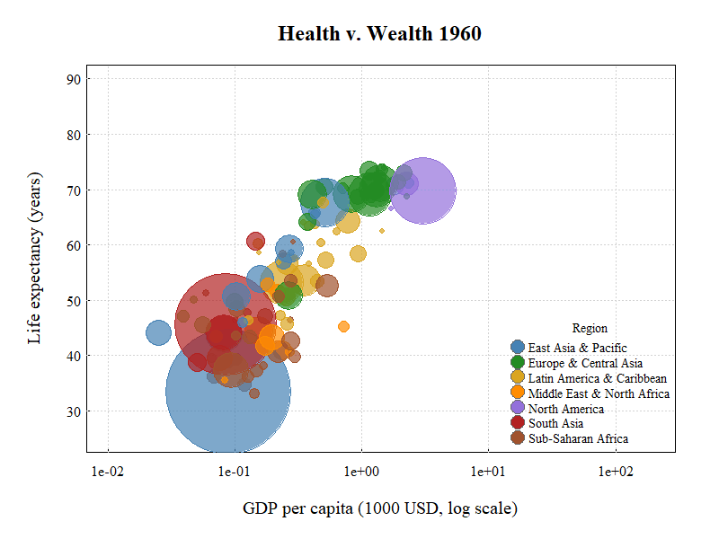

```r
library(magick)
pngs <- list.files("pngs", pattern = "*.png", full.names = TRUE)
frames <- image_read(pngs)
anim <- image_animate(frames, fps = 5)
image_write(anim, "HealthVWealth.gif")
```